# TidyTuesday Week 2: WHO TB

Author

Kent Glover

## Introduction and Setup

This report analyzes the TidyTuesday dataset for Week 2: WHO Tuberculosis data.

### 1. Load Libraries

First, load the necessary R packages. I also set a consistent `ggplot2` theme for all visualizations.

```r
library(tidyverse)
library(tidytuesdayR) #To load the Tidy Tuesday data
library(scales)       # For nice axis labels
library(ggrepel)      # For non overlapping text labels on plots
library(DT)           # For interactive data tables
library(here)


#set a consistent theme for all plots
theme_set(theme_minimal(base_size = 12))
```

### 2. Load Data

Next, use the `tidytuesdayR` package to download this week’s dataset.

```r
# load the data for the specified week
tuesdata <- tidytuesdayR::tt_load('2022-03-29')
who_tb_data <- tuesdata$tb

who_tb_data <- readr::read_csv('https://raw.githubusercontent.com/rfordatascience/tidytuesday/main/data/2025/2025-11-11/who_tb_data.csv')


glimpse(who_tb_data)
```

```
Rows: 5,117
Columns: 18
$ country               <chr> "Afghanistan", "Afghanistan", "Afghanistan", "Af…
$ g_whoregion           <chr> "Eastern Mediterranean", "Eastern Mediterranean"…
$ iso_numeric           <dbl> 4, 4, 4, 4, 4, 4, 4, 4, 4, 4, 4, 4, 4, 4, 4, 4, …
$ iso2                  <chr> "AF", "AF", "AF", "AF", "AF", "AF", "AF", "AF", …
$ iso3                  <chr> "AFG", "AFG", "AFG", "AFG", "AFG", "AFG", "AFG",…
$ year                  <dbl> 2000, 2001, 2002, 2003, 2004, 2005, 2006, 2007, …
$ c_cdr                 <dbl> 19, 26, 34, 32, 41, 47, 53, 59, 56, 50, 52, 50, …
$ c_newinc_100k         <dbl> 35, 50, 65, 61, 78, 90, 100, 111, 107, 95, 99, 9…
$ cfr                   <dbl> 0.37, 0.35, 0.31, 0.32, 0.28, 0.26, 0.24, 0.21, …
$ e_inc_100k            <dbl> 190, 189, 189, 189, 189, 189, 189, 189, 189, 189…
$ e_inc_num             <dbl> 38000, 38000, 40000, 43000, 44000, 46000, 48000,…
$ e_mort_100k           <dbl> 68.00, 63.00, 57.00, 58.00, 52.00, 47.00, 43.00,…
$ e_mort_exc_tbhiv_100k <dbl> 68.00, 63.00, 57.00, 58.00, 51.00, 47.00, 43.00,…
$ e_mort_exc_tbhiv_num  <dbl> 14000, 13000, 12000, 13000, 12000, 11000, 11000,…
$ e_mort_num            <dbl> 14000, 13000, 12000, 13000, 12000, 12000, 11000,…
$ e_mort_tbhiv_100k     <dbl> 0.17, 0.30, 0.27, 0.29, 0.29, 0.31, 0.32, 0.33, …
$ e_mort_tbhiv_num      <dbl> 34, 61, 58, 66, 67, 75, 82, 85, 96, 110, 120, 14…
$ e_pop_num             <dbl> 20130323, 20284311, 21378110, 22733047, 23560660…
```

## New Thing I Learned: Quarto Tabsets

For this week’s assignment, the new technique I learned was implementing **Quarto Tabsets**. This is a feature of Quarto that allows you to organize outputs (like plots, tables, and text) into a tabbed interface.

This is accomplished using markdown syntax (`::: {.panel-tabset}`… `:::`). This structure is perfect for this assignment, as it allows me to present the main analysis plot, a secondary contextual plot, and the underlying data table in an interactive component without forcing the user to scroll endlessly.

## Data Wrangling

The data dictionary shows two key mortality metrics: `e_mort_tbhiv_100k` (mortality in HIV-positive people) and `e_mort_exc_tbhiv_100k` (mortality excluding HIV).

To compare these two metrics in `ggplot2`, the data must be in a “long” format. The wrangling process is as follows:

1. Filter the data to a consistent time-frame (2000-2021) and remove rows with no WHO region (`g_whoregion`).
2. Use `pivot_longer()` to “melt” the two mortality columns into a single `population_group` column and a single `mortality_rate` column.
3. Clean up the new `population_group` names to be human-readable.
4. Group by `year`, `g_whoregion`, and our new `population_group`, then `summarise` to get the *mean* mortality rate.

```r
# 1.filter for a reasonable time-frame and where region is not NA
tb_data_filtered <- who_tb_data %>%
  filter(year >= 2000 & year <= 2021,!is.na(g_whoregion))

# 2. pivot to long format for ggplot
tb_data_long <- tb_data_filtered %>%
  select(country, year, g_whoregion,
         e_mort_tbhiv_100k, e_mort_exc_tbhiv_100k) %>%
  pivot_longer(
    cols = c(e_mort_tbhiv_100k, e_mort_exc_tbhiv_100k),
    names_to = "population_group",  #the new column for the old names
    values_to = "mortality_rate"    #the new column for the old values
  ) %>%
  # 3.Make the labels pretty for the plot legend
  mutate(population_group = case_when(
    population_group == "e_mort_tbhiv_100k" ~ "HIV-Positive",
    population_group == "e_mort_exc_tbhiv_100k" ~ "HIV-Negative"
  ))

# 4. summarize the data by region
mortality_summary <- tb_data_long %>%
  group_by(year, g_whoregion, population_group) %>%
  summarise(
    mean_mortality_rate = mean(mortality_rate, na.rm = TRUE),
  .groups = "drop" #Drop grouping after summarise
  )

#Check
glimpse(mortality_summary)
```

```
Rows: 264
Columns: 4
$ year                <dbl> 2000, 2000, 2000, 2000, 2000, 2000, 2000, 2000, 20…
$ g_whoregion         <chr> "Africa", "Africa", "Americas", "Americas", "Easte…
$ population_group    <chr> "HIV-Negative", "HIV-Positive", "HIV-Negative", "H…
$ mean_mortality_rate <dbl> 39.9313043, 73.2404348, 4.2851163, 1.9495349, 15.0…
```

## Analysis & Visualization

The following visualizations are presented in a tabset, the new Quarto feature I learned this week.

**Plot 1: Mortality (HIV+ vs. HIV-)**

This is the main plot for the assignment, focusing on best plotting practices. It visualizes the time-series (2000-2021) of mean TB mortality rates, comparing the HIV-Positive and HIV-Negative populations.

It uses `facet_wrap(~ g_whoregion)` to create “small multiples” for each WHO region. This is essential because the mortality rates are on vastly different scales. Setting `scales = "free_y"` allows each region’s plot to have its own y-axis, making the trends within each region visible.

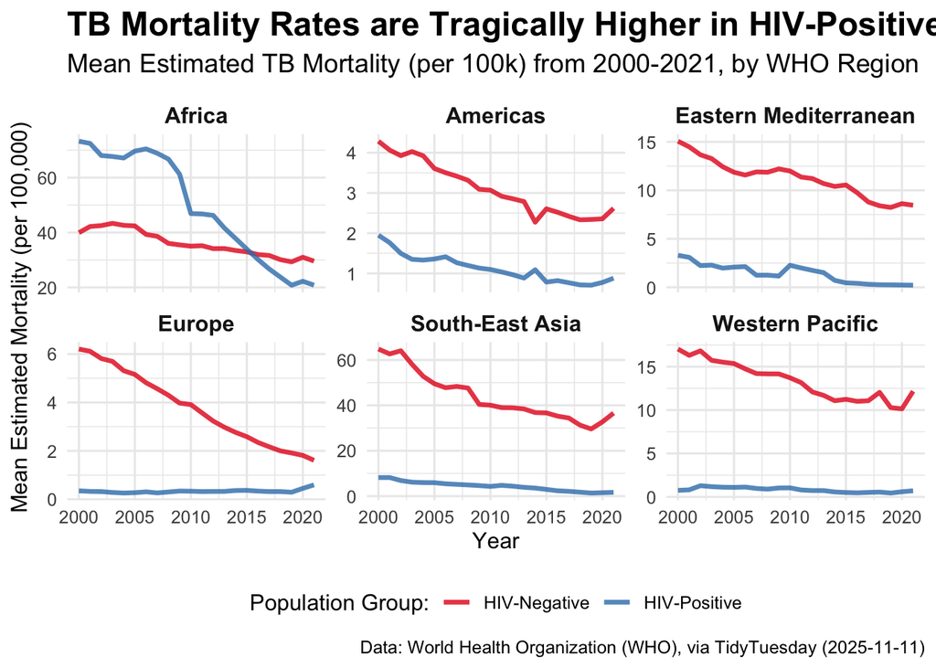

```r
main_plot <- mortality_summary %>%
  ggplot(aes(x = year,
             y = mean_mortality_rate,
             color = population_group)) +
  geom_line(linewidth = 1.2, alpha = 0.8) +

  # free_y because the rates are so different
  facet_wrap(~ g_whoregion, scales = "free_y") +

  #use scales::comma for readable y-axis
  scale_y_continuous(labels = scales::comma) +

  #use a high-contrast color palette
  scale_color_brewer(palette = "Set1") +

  #add all labels for a complete plot
  labs(
    title = "TB Mortality Rates are Tragically Higher in HIV-Positive Populations",
    subtitle = "Mean Estimated TB Mortality (per 100k) from 2000-2021, by WHO Region",
    x = "Year",
    y = "Mean Estimated Mortality (per 100,000)",
    color = "Population Group:",
    caption = "Data: World Health Organization (WHO), via TidyTuesday (2025-11-11)"
  ) +

  # clean theme move legend to the bottom
  theme_minimal(base_size = 12) +
  theme(
    legend.position = "bottom",
    strip.text = element_text(face = "bold", size = 12),
    plot.title = element_text(face = "bold", size = 18),
    plot.subtitle = element_text(size = 14, margin = margin(b = 10))
  )

# display the plot
main_plot
```

```r
#save the plot to the output folder
#create the directory if it doesn't exist
if (!dir.exists("output")) {
  dir.create("output")
}

ggsave("output/tb_mortality_by_hiv_status.png",
       plot = main_plot,
       width = 12, height = 8, dpi = 300)
```

**Plot 2: Incidence vs. Detection For Context**

This secondary plot provides context. It uses the most recent year of data (2021) to explore the relationship between TB *incidence* (`e_inc_100k`) and the *case detection rate* (`c_cdr`). My hypothesis is that high mortality is driven by high incidence and low detection.

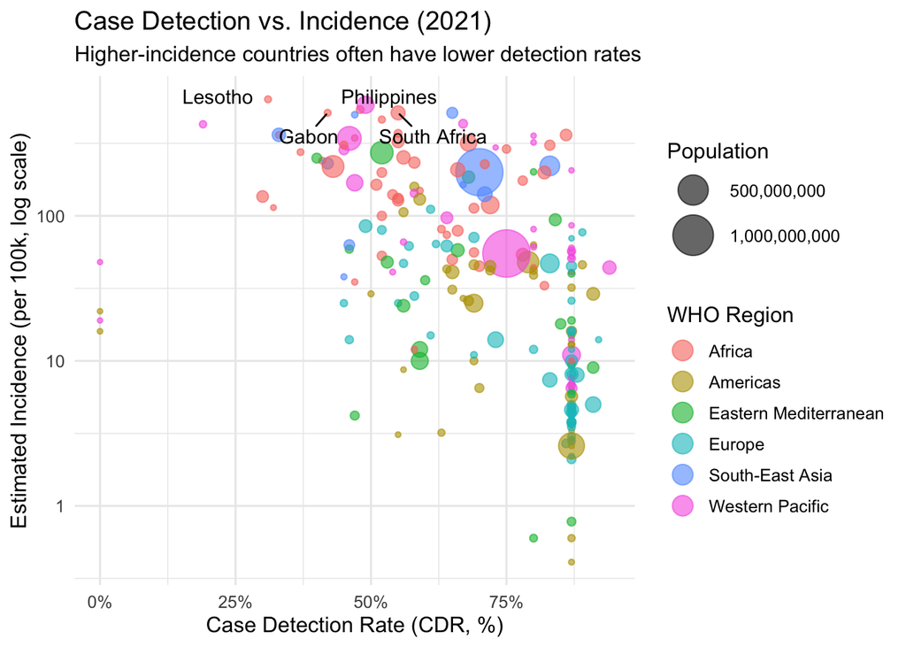

```r
#get data for the most recent year, 2021
context_data <- tb_data_filtered %>%
  filter(year == 2021) %>%
  #create a label for countries with very high incidence
  mutate(label = if_else(e_inc_100k > 500, country, NA_character_))

context_plot <- context_data %>%
  ggplot(aes(x = c_cdr, y = e_inc_100k)) +
  # map population to size + region to color
  geom_point(aes(color = g_whoregion, size = e_pop_num), alpha = 0.6) +

  # Use ggrepel for non-overlapping labels
  ggrepel::geom_text_repel(aes(label = label),
                           na.rm = TRUE,
                           seed = 42, #for reproducibility
                           box.padding = 0.5) +

  #format x-axis as percentage
  scale_x_continuous(labels = scales::percent_format(scale = 1)) +
  #ise a log scale for y-axis due to wide variance
  scale_y_log10(labels = scales::comma) +
  scale_size(range = c(1, 12), labels = scales::comma, name = "Population") +

  labs(
    title = "Case Detection vs. Incidence (2021)",
    subtitle = "Higher-incidence countries often have lower detection rates",
    x = "Case Detection Rate (CDR, %)",
    y = "Estimated Incidence (per 100k, log scale)",
    color = "WHO Region"
  ) +
  #improve legend readability
  guides(color = guide_legend(override.aes = list(size = 5))) +
  theme(legend.position = "right")

context_plot
```

**Analysis of the Plot:** This scatter plot shows a general negative relationship. Countries with very high TB incidence tend to have lower case detection rates. The labeled outliers (Lesotho, South Africa) are predominantly in the African region, which aligns with the first plot’s finding of extremely high mortality in that region.

**Tab 3: Filtered Data Table**

For transparency and reproducibility, here is the summarized data frame (`mortality_summary`) that was used to generate the main line plot in the first tab. The `DT::datatable` function is used to create an interactive table that is searchable.

```r
DT::datatable(
  mortality_summary,
  options = list(pageLength = 10, scrollX = TRUE),
  caption = "Table 1: Summarized mean mortality data used for the main plot.",
  rownames = FALSE,
  filter = 'top'
)
```

| year | g_whoregion | population_group | mean_mortality_rate |
| --- | --- | --- | --- |
| 2000 | Africa | HIV-Negative | 39.93130434782609 |
| 2000 | Africa | HIV-Positive | 73.2404347826087 |
| 2000 | Americas | HIV-Negative | 4.285116279069768 |
| 2000 | Americas | HIV-Positive | 1.94953488372093 |
| 2000 | Eastern Mediterranean | HIV-Negative | 15.06409090909091 |
| 2000 | Eastern Mediterranean | HIV-Positive | 3.298181818181818 |
| 2000 | Europe | HIV-Negative | 6.205576923076923 |
| 2000 | Europe | HIV-Positive | 0.3523076923076923 |
| 2000 | South-East Asia | HIV-Negative | 64.7875 |
| 2000 | South-East Asia | HIV-Positive | 8.198749999999999 |

[output cut: 254 more lines]